# (TMDb Movies Dataset Exploration)

## Preliminary Wrangling

> This document explores a dataset from TMDB .This data set contains information about 10,000 movies collected from The Movie Database (TMDb) that contain information about ( budget-revenue-original_title-cast homepage-director tagline -overview-runtime-genres-production_companies-release_date-vote_count-vote_average-release_year-budget_adj-revenue_adj)

```python
# import all packages and set plots to be embedded inline
import pandas as pd
import seaborn as sb
import os
import numpy as np
import matplotlib.pyplot as plt
%matplotlib inline
from pandas.api.types import CategoricalDtype
import datetime as dt
```

> Load in your dataset and describe its properties through the questions below. Try and motivate your exploration goals through this section.

```python
# Load your data from csv file
df_movies = pd.read_csv('D://tmdb-movies.csv')
```

```python
# high-level overview of data shape and composition
print(df_movies.shape)
print(df_movies.dtypes)
print(df_movies.head(10))
```

```
(10866, 21)
id                        int64
imdb_id                  object
popularity              float64
budget                    int64
revenue                   int64
original_title           object
cast                     object
homepage                 object
director                 object
tagline                  object
keywords                 object
overview                 object
runtime                   int64
genres                   object
```

[output cut: 129 more lines]

```python
# descriptive statistics for numeric variables
print(df_movies.describe())
```

```
                  id    popularity        budget       revenue       runtime  \
count   10866.000000  10866.000000  1.086600e+04  1.086600e+04  10866.000000
mean    66064.177434      0.646441  1.462570e+07  3.982332e+07    102.070863
std     92130.136561      1.000185  3.091321e+07  1.170035e+08     31.381405
min         5.000000      0.000065  0.000000e+00  0.000000e+00      0.000000
25%     10596.250000      0.207583  0.000000e+00  0.000000e+00     90.000000
50%     20669.000000      0.383856  0.000000e+00  0.000000e+00     99.000000
75%     75610.000000      0.713817  1.500000e+07  2.400000e+07    111.000000
max    417859.000000     32.985763  4.250000e+08  2.781506e+09    900.000000

         vote_count  vote_average  release_year    budget_adj   revenue_adj
count  10866.000000  10866.000000  10866.000000  1.086600e+04  1.086600e+04
mean     217.389748      5.974922   2001.322658  1.755104e+07  5.136436e+07
std      575.619058      0.935142     12.812941  3.430616e+07  1.446325e+08
min       10.000000      1.500000   1960.000000  0.000000e+00  0.000000e+00
25%       17.000000      5.400000   1995.000000  0.000000e+00  0.000000e+00
50%       38.000000      6.000000   2006.000000  0.000000e+00  0.000000e+00
75%      145.750000      6.600000   2011.000000  2.085325e+07  3.369710e+07
max     9767.000000      9.200000   2015.000000  4.250000e+08  2.827124e+09
```

# I made some cleaning in this dataset so i will create copy from the original dataset..

```python
#copy the original file (csv file ) to another copy file
df_clean_movies = df_movies.copy()
```

```python
#Remove columns that are not useful for answering questions (popularity,homepage,cast, Tagline, Keywords and Overview)
df_clean_movies.drop(df_clean_movies.columns[[0,1,2,3,4,7,9,10,11]],axis=1 , inplace=True)
```

```python
#drop the dupliacted film title
df_clean_movies.drop_duplicates(subset="original_title")
```

|  | original_title | cast | director | runtime | genres | production_companies | release_date | vote_count | vote_average | release_year | budget_adj | revenue_adj |
| --- | --- | --- | --- | --- | --- | --- | --- | --- | --- | --- | --- | --- |
| 0 | Jurassic World | Chris Pratt\|Bryce Dallas Howard\|Irrfan Khan\|Vi... | Colin Trevorrow | 124 | Action\|Adventure\|Science Fiction\|Thriller | Universal Studios\|Amblin Entertainment\|Legenda... | 6/9/15 | 5562 | 6.5 | 2015 | 1.379999e+08 | 1.392446e+09 |
| 1 | Mad Max: Fury Road | Tom Hardy\|Charlize Theron\|Hugh Keays-Byrne\|Nic... | George Miller | 120 | Action\|Adventure\|Science Fiction\|Thriller | Village Roadshow Pictures\|Kennedy Miller Produ... | 5/13/15 | 6185 | 7.1 | 2015 | 1.379999e+08 | 3.481613e+08 |
| 2 | Insurgent | Shailene Woodley\|Theo James\|Kate Winslet\|Ansel... | Robert Schwentke | 119 | Adventure\|Science Fiction\|Thriller | Summit Entertainment\|Mandeville Films\|Red Wago... | 3/18/15 | 2480 | 6.3 | 2015 | 1.012000e+08 | 2.716190e+08 |
| 3 | Star Wars: The Force Awakens | Harrison Ford\|Mark Hamill\|Carrie Fisher\|Adam D... | J.J. Abrams | 136 | Action\|Adventure\|Science Fiction\|Fantasy | Lucasfilm\|Truenorth Productions\|Bad Robot | 12/15/15 | 5292 | 7.5 | 2015 | 1.839999e+08 | 1.902723e+09 |
| 4 | Furious 7 | Vin Diesel\|Paul Walker\|Jason Statham\|Michelle ... | James Wan | 137 | Action\|Crime\|Thriller | Universal Pictures\|Original Film\|Media Rights ... | 4/1/15 | 2947 | 7.3 | 2015 | 1.747999e+08 | 1.385749e+09 |
| ... | ... | ... | ... | ... | ... | ... | ... | ... | ... | ... | ... | ... |
| 10861 | The Endless Summer | Michael Hynson\|Robert August\|Lord 'Tally Ho' B... | Bruce Brown | 95 | Documentary | Bruce Brown Films | 6/15/66 | 11 | 7.4 | 1966 | 0.000000e+00 | 0.000000e+00 |
| 10862 | Grand Prix | James Garner\|Eva Marie Saint\|Yves Montand\|Tosh... | John Frankenheimer | 176 | Action\|Adventure\|Drama | Cherokee Productions\|Joel Productions\|Douglas ... | 12/21/66 | 20 | 5.7 | 1966 | 0.000000e+00 | 0.000000e+00 |
| 10863 | Beregis Avtomobilya | Innokentiy Smoktunovskiy\|Oleg Efremov\|Georgi Z... | Eldar Ryazanov | 94 | Mystery\|Comedy | Mosfilm | 1/1/66 | 11 | 6.5 | 1966 | 0.000000e+00 | 0.000000e+00 |
| 10864 | What's Up, Tiger Lily? | Tatsuya Mihashi\|Akiko Wakabayashi\|Mie Hama\|Joh... | Woody Allen | 80 | Action\|Comedy | Benedict Pictures Corp. | 11/2/66 | 22 | 5.4 | 1966 | 0.000000e+00 | 0.000000e+00 |
| 10865 | Manos: The Hands of Fate | Harold P. Warren\|Tom Neyman\|John Reynolds\|Dian... | Harold P. Warren | 74 | Horror | Norm-Iris | 11/15/66 | 15 | 1.5 | 1966 | 1.276423e+05 | 0.000000e+00 |

10571 rows × 12 columns

```python
# make the release_date column type to date time type
df_clean_movies['release_date'] = pd.to_datetime(df_clean_movies['release_date'])
```

```python
df_clean_movies['production_companies'] .mode()
```

```
0    Paramount Pictures
dtype: object
```

```python
df_clean_movies['director'] .mode()
```

```
0    Woody Allen
dtype: object
```

```python
df_clean_movies['genres'] .mode()
```

```
0    Comedy
1     Drama
dtype: object
```

```python
#fill the nullvalue
df_clean_movies['production_companies'] = df_clean_movies['production_companies'].fillna(df_clean_movies['production_companies'] .mode())
df_clean_movies['director'] = df_clean_movies['director'].fillna(df_clean_movies['director'] .mode())
df_clean_movies['genres'] = df_clean_movies['genres'].fillna(df_clean_movies['genres'] .mode())
```

```python
# fill zeroos value to the mean value for this column(budget,revenue,budget_adj,revenue_adj)
mean_budget_adj = df_clean_movies['budget_adj'].mean()
df_clean_movies['budget_adj'] = df_clean_movies['budget_adj'].replace(0,mean_budget_adj)

mean_revenue_adj = df_clean_movies['revenue_adj'].mean()
df_clean_movies['revenue_adj'] = df_clean_movies['revenue_adj'].replace(0,mean_revenue_adj)
```

```python
# delete the outliers from releas date that greater than the current date
outliers = df_clean_movies[df_clean_movies.release_date > dt.datetime.now()][['release_date']]
df_clean_movies.drop(df_clean_movies.loc[df_clean_movies['release_date']>dt.datetime.now()].index, inplace=True)
```

```python
#add profit column
df_clean_movies['profit'] = df_clean_movies['revenue_adj'] - df_clean_movies['budget_adj']
```

```python
# extract the month name from the release date
df_clean_movies['month'] = pd.to_datetime(df_clean_movies['release_date'], format='%m').dt.month_name().str.slice(stop=3)
```

```python
# Columns to convert datatype of
columns = ['budget_adj','revenue_adj','profit']
# Convert budget and revenue column to int datatype
df_clean_movies[columns] = df_clean_movies[columns].applymap(np.int64)
# Lets look at the new datatype
df_clean_movies.dtypes
```

```
original_title                  object
cast                            object
director                        object
runtime                          int64
genres                          object
production_companies            object
release_date            datetime64[ns]
vote_count                       int64
vote_average                   float64
release_year                     int64
budget_adj                       int64
revenue_adj                      int64
profit                           int64
month                           object
dtype: object
```

```python
# high-level overview of data shape and composition
print(df_clean_movies.shape)
print(df_clean_movies.dtypes)
```

```
(10463, 14)
original_title                  object
cast                            object
director                        object
runtime                          int64
genres                          object
production_companies            object
release_date            datetime64[ns]
vote_count                       int64
vote_average                   float64
release_year                     int64
budget_adj                       int64
revenue_adj                      int64
profit                           int64
month                           object
dtype: object
```

```python
df_clean_movies.describe()
```

|  | runtime | vote_count | vote_average | release_year | budget_adj | revenue_adj | profit |
| --- | --- | --- | --- | --- | --- | --- | --- |
| count | 10463.000000 | 10463.000000 | 10463.000000 | 10463.000000 | 1.046300e+04 | 1.046300e+04 | 1.046300e+04 |
| mean | 101.708401 | 223.127497 | 5.963806 | 2002.713849 | 2.689559e+07 | 7.910504e+07 | 5.220945e+07 |
| std | 31.288089 | 585.007590 | 0.938830 | 10.860058 | 3.073064e+07 | 1.351084e+08 | 1.186905e+08 |
| min | 0.000000 | 10.000000 | 1.500000 | 1971.000000 | 0.000000e+00 | 2.000000e+00 | -4.139124e+08 |
| 25% | 90.000000 | 17.000000 | 5.400000 | 1996.000000 | 1.755104e+07 | 5.136436e+07 | 1.809817e+07 |
| 50% | 98.000000 | 40.000000 | 6.000000 | 2006.000000 | 1.755104e+07 | 5.136436e+07 | 3.381332e+07 |
| 75% | 111.000000 | 151.000000 | 6.600000 | 2011.000000 | 2.103337e+07 | 5.136436e+07 | 3.896975e+07 |
| max | 900.000000 | 9767.000000 | 9.200000 | 2015.000000 | 4.250000e+08 | 2.827124e+09 | 2.750137e+09 |

```python
df_clean_movies.head(10)
```

|  | original_title | cast | director | runtime | genres | production_companies | release_date | vote_count | vote_average | release_year | budget_adj | revenue_adj | profit | month |
| --- | --- | --- | --- | --- | --- | --- | --- | --- | --- | --- | --- | --- | --- | --- |
| 0 | Jurassic World | Chris Pratt\|Bryce Dallas Howard\|Irrfan Khan\|Vi... | Colin Trevorrow | 124 | Action\|Adventure\|Science Fiction\|Thriller | Universal Studios\|Amblin Entertainment\|Legenda... | 2015-06-09 | 5562 | 6.5 | 2015 | 137999939 | 1392445892 | 1254445953 | Jun |
| 1 | Mad Max: Fury Road | Tom Hardy\|Charlize Theron\|Hugh Keays-Byrne\|Nic... | George Miller | 120 | Action\|Adventure\|Science Fiction\|Thriller | Village Roadshow Pictures\|Kennedy Miller Produ... | 2015-05-13 | 6185 | 7.1 | 2015 | 137999939 | 348161292 | 210161353 | May |
| 2 | Insurgent | Shailene Woodley\|Theo James\|Kate Winslet\|Ansel... | Robert Schwentke | 119 | Adventure\|Science Fiction\|Thriller | Summit Entertainment\|Mandeville Films\|Red Wago... | 2015-03-18 | 2480 | 6.3 | 2015 | 101199955 | 271619025 | 170419069 | Mar |
| 3 | Star Wars: The Force Awakens | Harrison Ford\|Mark Hamill\|Carrie Fisher\|Adam D... | J.J. Abrams | 136 | Action\|Adventure\|Science Fiction\|Fantasy | Lucasfilm\|Truenorth Productions\|Bad Robot | 2015-12-15 | 5292 | 7.5 | 2015 | 183999919 | 1902723129 | 1718723210 | Dec |
| 4 | Furious 7 | Vin Diesel\|Paul Walker\|Jason Statham\|Michelle ... | James Wan | 137 | Action\|Crime\|Thriller | Universal Pictures\|Original Film\|Media Rights ... | 2015-04-01 | 2947 | 7.3 | 2015 | 174799923 | 1385748801 | 1210948878 | Apr |
| 5 | The Revenant | Leonardo DiCaprio\|Tom Hardy\|Will Poulter\|Domhn... | Alejandro González Iñárritu | 156 | Western\|Drama\|Adventure\|Thriller | Regency Enterprises\|Appian Way\|CatchPlay\|Anony... | 2015-12-25 | 3929 | 7.2 | 2015 | 124199945 | 490314247 | 366114301 | Dec |
| 6 | Terminator Genisys | Arnold Schwarzenegger\|Jason Clarke\|Emilia Clar... | Alan Taylor | 125 | Science Fiction\|Action\|Thriller\|Adventure | Paramount Pictures\|Skydance Productions | 2015-06-23 | 2598 | 5.8 | 2015 | 142599937 | 405355075 | 262755138 | Jun |
| 7 | The Martian | Matt Damon\|Jessica Chastain\|Kristen Wiig\|Jeff ... | Ridley Scott | 141 | Drama\|Adventure\|Science Fiction | Twentieth Century Fox Film Corporation\|Scott F... | 2015-09-30 | 4572 | 7.6 | 2015 | 99359956 | 547749654 | 448389698 | Sep |
| 8 | Minions | Sandra Bullock\|Jon Hamm\|Michael Keaton\|Allison... | Kyle Balda\|Pierre Coffin | 91 | Family\|Animation\|Adventure\|Comedy | Universal Pictures\|Illumination Entertainment | 2015-06-17 | 2893 | 6.5 | 2015 | 68079970 | 1064192016 | 996112046 | Jun |
| 9 | Inside Out | Amy Poehler\|Phyllis Smith\|Richard Kind\|Bill Ha... | Pete Docter | 94 | Comedy\|Animation\|Family | Walt Disney Pictures\|Pixar Animation Studios\|W... | 2015-06-09 | 3935 | 8.0 | 2015 | 160999929 | 785411574 | 624411645 | Jun |

### What is the structure of your dataset?

(worst) ——> (best) vote_average: from 1 to 10

### What is/are the main feature(s) of interest in your dataset?

> I'm most interested in figuring out what features are best types of movies with high profit and which the best production companies that recorded high profit! which type of movies that recorded high voting from users.

### What features in the dataset do you think will help support your investigation into your feature(s) of interest?

> I expect that the profit will have the strongest effect on each movie. who is the actors the act in most of movies? which company that produced most of movies per years?

## Univariate Exploration

> In this section, I'll start by looking at the distribution of the main variable of interest: profit..

--------------------------Preview overall distribution of data from each properties----------------------------------------

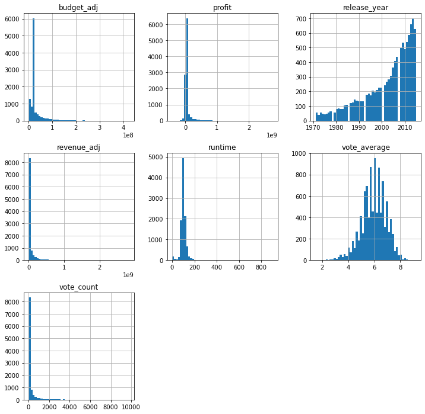

```python
# Preview overall distribution of data from each properties
df_clean_movies.hist(figsize = (12,12), bins = 50);
```

-----------------------------------------About number of movies per years---------------------------------------------------

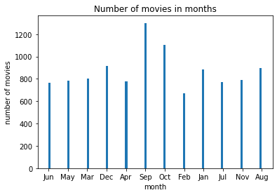

```python
# start with a standard-scaled plot
#plt.figure(figsize=[8, 5])
plt.hist(data = df_clean_movies, x = 'month' , bins = 100)
plt.xlabel('month')
plt.ylabel('number of movies')
plt.title('Number of movies in months')
plt.show()
```

The highst number of movies released in september

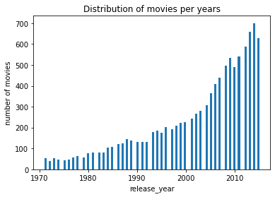

```python
# start with a standard-scaled plot
#plt.figure(figsize=[8, 5])
plt.hist(data = df_clean_movies, x = 'release_year' , bins = 100)
plt.xlabel('release_year')
plt.ylabel('number of movies')
plt.title('Distribution of movies per years')
plt.show()
```

This is left skweed shape.. the number of movies increased per years and the most number of movies after 2010

----------------------------------------------------About genres data----------------------------------------------------------

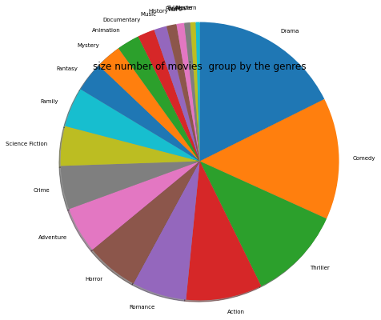

```python
# i used the value count to calculate how many movies per genres
genres_count = pd.Series(df_clean_movies['genres'].str.cat(sep = '|').split('|')).value_counts(ascending = False)
genres_count
textprops = {"fontsize":7}
plt.pie(genres_count, labels = genres_count.index, startangle = 90, counterclock = False,radius = 2,textprops =textprops, shadow=True);
plt.title('size number of movies  group by the genres')
```

```python
genres_count = pd.Series(df_clean_movies['genres'].str.cat(sep = '|').split('|')).value_counts(ascending = False)
genres_count
```

```
Drama              4574
Comedy             3668
Thriller           2839
Action             2296
Romance            1639
Horror             1585
Adventure          1401
Crime              1308
Science Fiction    1193
Family             1189
Fantasy             890
Mystery             775
Animation           681
Documentary         515
Music               383
History             300
War                 234
Foreign             178
TV Movie            164
Western             121
dtype: int64
```

```
Total number of genres is : 20
```

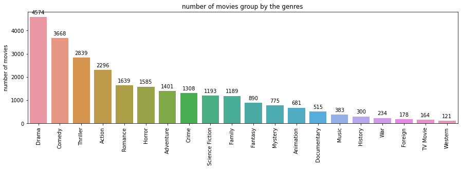

```python
plt.figure(figsize=(15,4))
plt.ylabel('number of movies')
plt.title('number of movies group by the genres')
print (f'Total number of genres is : {len(genres_count)}')

sb.barplot(genres_count.index.values, genres_count)
# get the current tick locations and labels
plt.xticks(rotation=90)
# Logic to print value on each bar
for i in range (genres_count.shape[0]):
    count = genres_count[i]

    plt.text(i, count+300, count, ha = 'center', va='top')
```

The darama genera has 4574 movies in this dataset.. that is the highst number for movies count.

----------------------The visualiztions about the production companies-----------------------------------------------------------

```python
pcompanies_count = pd.Series(df_clean_movies['production_companies'].str.cat(sep = '|').split('|')).value_counts(ascending = False)
pcompanies_count[:10]
```

```
Universal Pictures                        502
Warner Bros.                              491
Paramount Pictures                        407
Columbia Pictures                         265
Twentieth Century Fox Film Corporation    252
New Line Cinema                           219
Walt Disney Pictures                      210
Metro-Goldwyn-Mayer (MGM)                 185
Touchstone Pictures                       178
TriStar Pictures                          147
dtype: int64
```

```
Total number of production_companies is : 7653
```

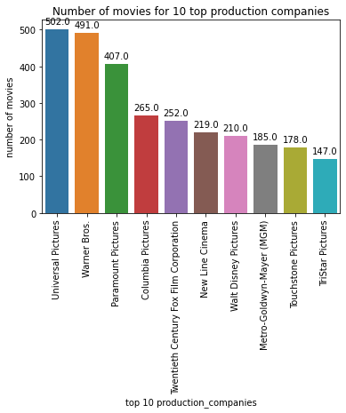

```python
plt.figure() #figsize=(400,200))
print (f'Total number of production_companies is : {len(pcompanies_count)}')
#  i will show the top 10 compnies only
pcompanies_count = pcompanies_count[:10]
splot = sb.barplot(pcompanies_count.index.values, pcompanies_count)
# get the current tick locations and labels
plt.xticks(rotation=90)
# Logic to print value on each bar
for p in splot.patches:
    plt.annotate(format(p.get_height(), '.1f'),
                   (p.get_x() + p.get_width() / 2., p.get_height()),
                   ha = 'center', va = 'center',
                   xytext = (0, 9),
                   textcoords = 'offset points')

plt.ylabel('number of movies')
plt.xlabel('top 10 production_companies')
plt.title('Number of movies for 10 top production companies')
plt.show()
```

Universal Pictures 502

Warner Bros. 491

Paramount Pictures 407

Columbia Pictures 265

Twentieth Century Fox Film Corporation 252

New Line Cinema 219

Metro-Goldwyn-Mayer (MGM) 185

Touchstone Pictures 178

TriStar Pictures 147

--------------------------------------the visualiztaion for actors in this dataset---------------------------------------------

```python
cast_count = pd.Series(df_clean_movies['cast'].str.cat(sep = '|').split('|')).value_counts(ascending = False)
cast_count[:10]
```

```
Robert De Niro       72
Samuel L. Jackson    71
Bruce Willis         62
Nicolas Cage         61
Robin Williams       51
John Cusack          50
Morgan Freeman       49
John Goodman         49
Susan Sarandon       48
Liam Neeson          48
dtype: int64
```

```
the total number of cast is : 18264
```

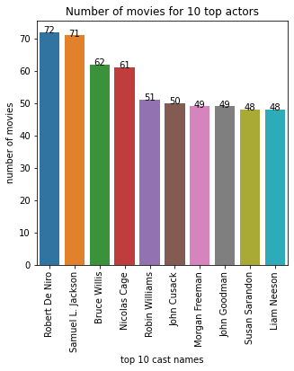

```python
plt.figure(figsize=(5,5))
print (f'the total number of cast is : {len(cast_count)}')
#  i will show the top 10 compnies only
cast_count = cast_count[:10]
sb.barplot(cast_count.index.values, cast_count)
# get the current tick locations and labels
plt.xticks(rotation=90)
# Logic to print value on each bar
for i in range (cast_count.shape[0]):
    count = cast_count[i]

    plt.text(i, count+2, count, ha = 'center', va='top')

plt.ylabel('number of movies')
plt.xlabel('top 10 cast names')
plt.title('Number of movies for 10 top actors')
```

There are 18264 actors in this data set. the top 10 actors are

Robert De Niro 72

Samuel L. Jackson 71

Bruce Willis 62

Nicolas Cage 61

Robin Williams 51

John Cusack 50

John Goodman 49

Morgan Freeman 49

Susan Sarandon 48

Liam Neeson 48

```python
director_count = pd.Series(df_clean_movies['director'].str.cat(sep = '|').split('|')).value_counts(ascending = False)
director_count[:10]
```

```
Woody Allen          44
Clint Eastwood       34
Steven Spielberg     30
Martin Scorsese      29
Ridley Scott         23
Steven Soderbergh    23
Ron Howard           22
Joel Schumacher      21
Brian De Palma       20
Tim Burton           20
dtype: int64
```

```
Total number of director is : 5239
```

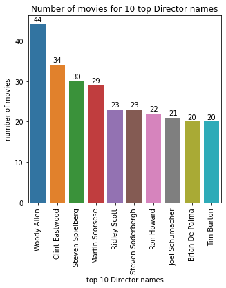

```python
plt.figure(figsize=(5,5))
print (f'Total number of director is : {len(director_count)}')
#  i will show the top 10 compnies only
director_count = director_count[:10]
sb.barplot(director_count.index.values, director_count)
# get the current tick locations and labels
plt.xticks(rotation=90)
# Logic to print value on each bar
for i in range (director_count.shape[0]):
    count = director_count[i]

    plt.text(i, count+2, count, ha = 'center', va='top')

plt.ylabel('number of movies')
plt.xlabel('top 10 Director names')
plt.title('Number of movies for 10 top Director names')
```

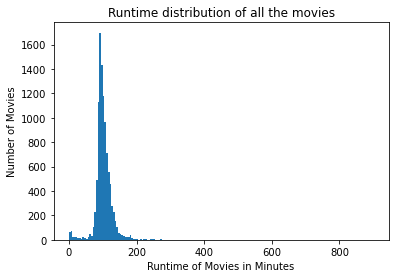

```python
bins = np.arange(0, df_clean_movies['runtime'].max()+5, 5)
# x-axis
plt.xlabel('Runtime of Movies in Minutes')
# y-axis
plt.ylabel('Number of Movies')
# Title of the histogram
plt.title('Runtime distribution of all the movies')
# Plot a histogram
plt.hist(df_clean_movies['runtime'], bins = bins)
```

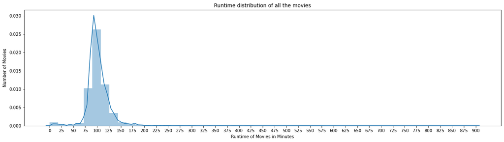

```python
plt.subplots(1,1,figsize=(20, 5))
ax = sb.distplot(df_clean_movies['runtime'])
ax.set_xticks(np.arange(0, df_clean_movies['runtime'].max()+1, 25))
plt.title('Runtime distribution of all the movies')
plt.xlabel('Runtime of Movies in Minutes')
# y-axis
plt.ylabel('Number of Movies')
plt.show()
```

```python
df_clean_movies['profit'].describe()
```

```
count    1.046300e+04
mean     5.220945e+07
std      1.186905e+08
min     -4.139124e+08
25%      1.809817e+07
50%      3.381332e+07
75%      3.896975e+07
max      2.750137e+09
Name: profit, dtype: float64
```

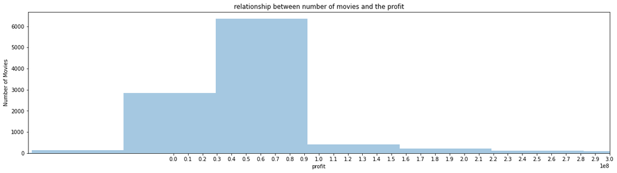

```python
plt.subplots(1,1,figsize=(20, 5))
ax = sb.distplot(df_clean_movies['profit'], kde=False)
ax.set_xticks(np.arange(0, df_clean_movies['profit'].max()+1, 10000000))
ax.set_xlim(-0.1*1e9, 0.3*1e9)
plt.title('relationship between number of movies and the profit')
plt.xlabel('profit')
# y-axis
plt.ylabel('Number of Movies')
plt.show()
```

Most of the profit lies between 0 & 100M . there are more of outliers so i go to investigate with boxplot

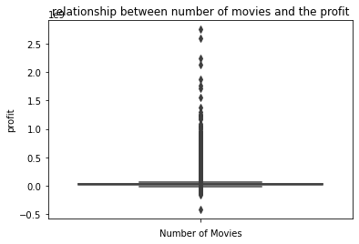

```python
sb.boxplot(data=df_clean_movies, y='profit')
plt.title('relationship between number of movies and the profit')
plt.ylabel('profit')
# y-axis
plt.xlabel('Number of Movies')
plt.show()
```

There are alot of outliers in the profits data.. i cant drop this data .. i left it because it is large amount with reflix in the all visualization for these data

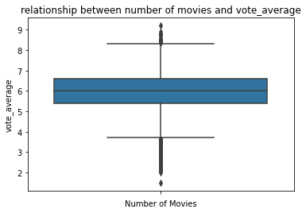

```python
sb.boxplot(data=df_clean_movies, y='vote_average')
plt.title('relationship between number of movies and vote_average')
plt.ylabel('vote_average')
# y-axis
plt.xlabel('Number of Movies')
plt.show()
```

The most values in "vote_averge" between 5.5 to 6.5

> Make sure that, after every plot or related series of plots, that you include a Markdown cell with comments about what you observed, and what you plan on investigating next.

## Bivariate Exploration

------------------The relationhips between (revenue - bugdet)-------------------------------------------

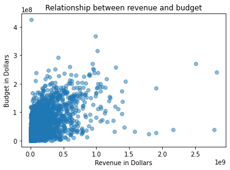

```python
# x-axis
plt.xlabel('Revenue in Dollars')
# y-axis
plt.ylabel('Budget in Dollars')
# Title of the histogram
plt.title('Relationship between revenue and budget')
plt.scatter(df_clean_movies['revenue_adj'], df_clean_movies['budget_adj'], alpha=0.5)
plt.show()
```

The most of movies revenue lies in (0.0*1e9 - 0.5*1e9 dollars) and budget lies in (0*1e8 - 1*1e8 dollares)

----------------------------The relationship between (budget - profit)-----------------------------------------------------

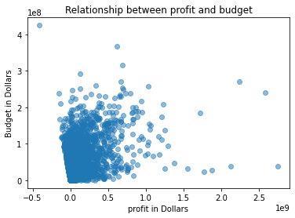

```python
# x-axis
plt.xlabel('profit in Dollars')
# y-axis
plt.ylabel('Budget in Dollars')
# Title of the histogram
plt.title('Relationship between profit and budget')
plt.scatter(df_clean_movies['profit'], df_clean_movies['budget_adj'], alpha=0.5)
plt.show()
```

There are little movies have high profit with low bugdet but most of profit lies between (0.0 *1e9 to 0.5*1e9) and budget(0.1e8 to 1*1e8 dollars)

```python
df_clean_movies.info()
```

```
<class 'pandas.core.frame.DataFrame'>
Int64Index: 10463 entries, 0 to 10819
Data columns (total 14 columns):
 #   Column                Non-Null Count  Dtype
---  ------                --------------  -----
 0   original_title        10463 non-null  object
 1   cast                  10390 non-null  object
 2   director              10420 non-null  object
 3   runtime               10463 non-null  int64
 4   genres                10441 non-null  object
 5   production_companies  9446 non-null   object
 6   release_date          10463 non-null  datetime64[ns]
 7   vote_count            10463 non-null  int64
 8   vote_average          10463 non-null  float64
 9   release_year          10463 non-null  int64
 10  budget_adj            10463 non-null  int64
 11  revenue_adj           10463 non-null  int64
 12  profit                10463 non-null  int64
 13  month                 10463 non-null  object
dtypes: datetime64[ns](1), float64(1), int64(6), object(6)
memory usage: 1.2+ MB
```

```python
numeric_vars = ['profit', 'budget_adj', 'revenue_adj', 'vote_average']
categoric_vars = ['genres', 'production_companies', 'cast','director','release_year','month']
```

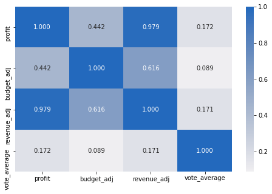

```python
# correlation plot
plt.figure(figsize = [8, 5])
sb.heatmap(df_clean_movies[numeric_vars].corr(), annot = True, fmt = '.3f',
           cmap = 'vlag_r', center = 0)
plt.show()
```

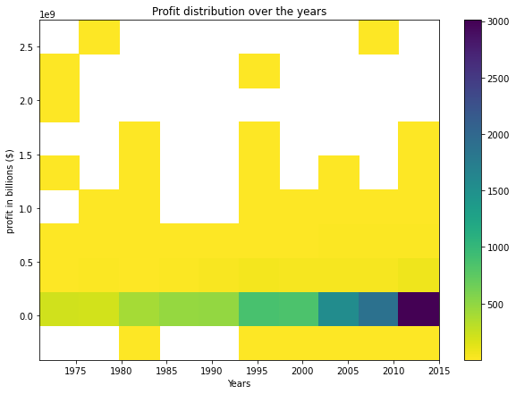

```python
plt.figure(figsize = [10, 7])
plt.title('Profit distribution over the years');
h2d = plt.hist2d(data = df_clean_movies, x = 'release_year', y = 'profit', cmin=0.5, cmap='viridis_r')
plt.colorbar()
plt.ylabel('profit in billions ($)');
plt.xlabel('Years')
```

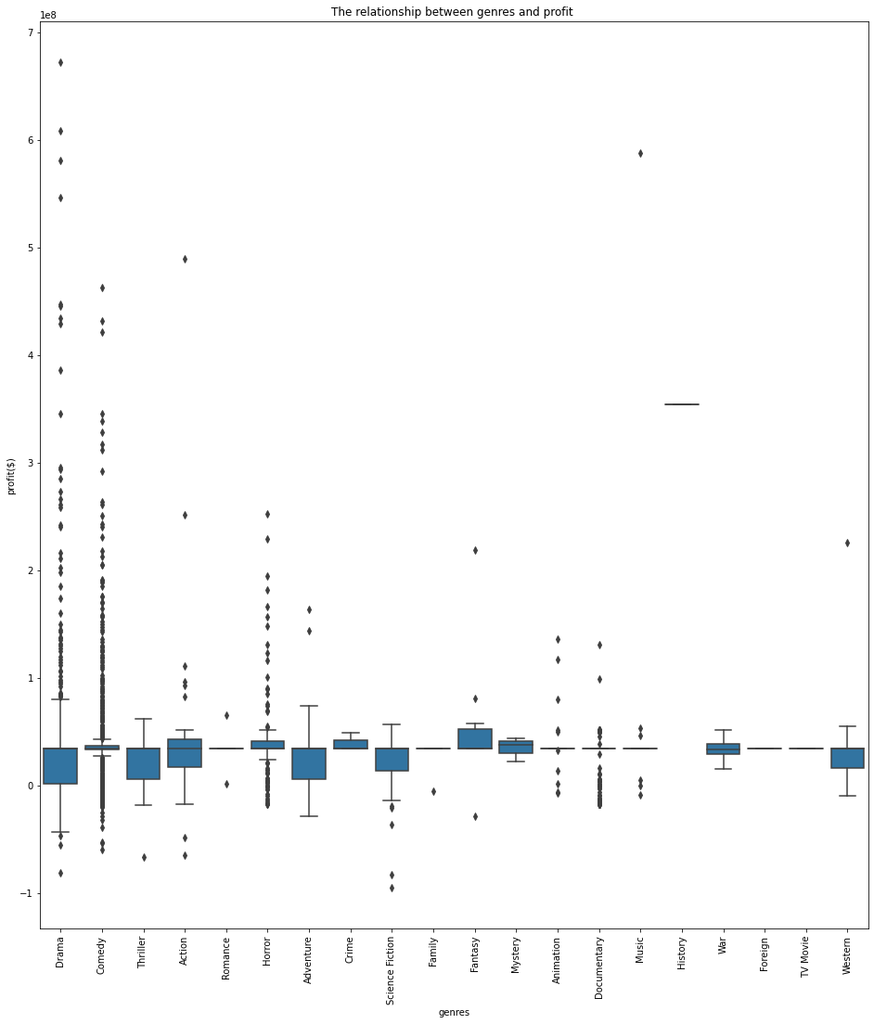

```python
# Types of movies
movies_classes = ['Drama','Comedy','Thriller','Action','Romance','Horror','Adventure','Crime','Science Fiction','Family','Fantasy','Mystery','Animation','Documentary','Music','History','War','Foreign','TV Movie','Western']
vclasses = pd.api.types.CategoricalDtype(ordered=True, categories=movies_classes)

# Use pandas.astype() to convert the "VClass" column from a plain object type into an ordered categorical type
df_clean_movies['genres'] = df_clean_movies['genres'].astype(vclasses);

plt.figure(figsize = [16, 18])
base_color = sb.color_palette()[0]
#Let's return the axes object
ax1 = sb.boxplot(data=df_clean_movies, x='genres', y='profit', color=base_color)
plt.xticks(rotation=90);

plt.title('The relationship between genres and profit ');
plt.ylabel('profit($)');
plt.xlabel('genres')
```

[figure not shown]

```python
plt.figure(figsize = [16, 5])
# Convert the "VClass" column from a plain object type into an ordered categorical type
movies_classes = ['Drama','Comedy','Thriller','Action','Romance','Horror','Adventure','Crime','Science Fiction','Family','Fantasy','Mystery','Animation','Documentary','Music','History','War','Foreign','TV Movie','Western']
vclasses = pd.api.types.CategoricalDtype(ordered=True, categories=movies_classes)
df_clean_movies['genres'] = df_clean_movies['genres'].astype(vclasses);

# Plot the Seaborn's FacetGrid
g = sb.FacetGrid(data = df_clean_movies, col = 'genres')
g.map(plt.hist, "profit")

plt.title('The relationship between number of movies per genres and profit ');
plt.ylabel('number of movies');
plt.xlabel('profit')
```

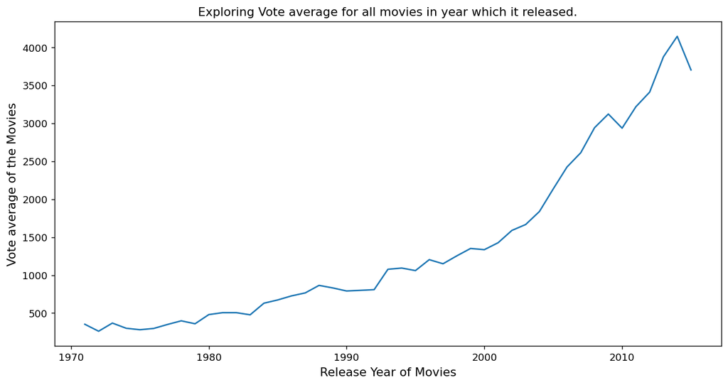

```python
vote = df_clean_movies.groupby('release_year')['vote_average'].sum()

#giving the figure size(width, height)
plt.figure(figsize=(12,6), dpi = 130)

#labeling x-axis
plt.xlabel('Release Year of Movies', fontsize = 12)
#labeling y-axis
plt.ylabel('Vote average of the Movies', fontsize = 12)
#title of a the plot
plt.title('Exploring Vote average for all movies in year which it released.')
#plotting what needs to be plotted
plt.plot(vote)
#showing the plot
plt.show()
```

### Talk about some of the relationships you observed in this part of the investigation. How did the feature(s) of interest vary with other features in the dataset?

> There was an interesting relationship observed between profit and the categorical features For genera of movies . the highst profit were associated with increasing the budget. I am interested in studying the factors affecting profits and I noticed that profits increased significantly between 2000 and 2015

## Multivariate Exploration

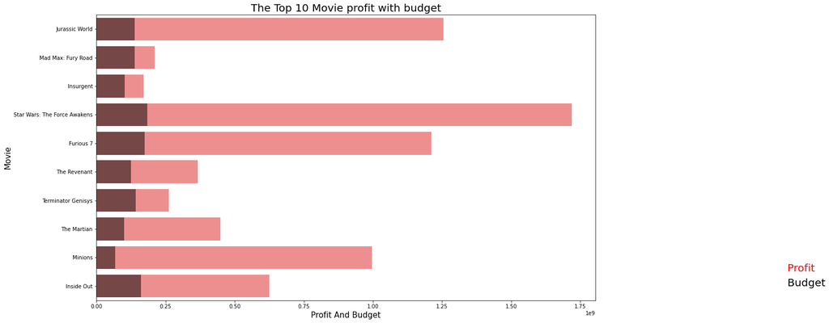

```python
#plot the first 10 Movie profit with budget
plt.figure(figsize = (17,10))
sb.barplot(x = "profit",y= "original_title", data=  df_clean_movies.head(10),color="red",alpha=0.5,Label="Profit")
sb.barplot(x = "budget_adj", y = "original_title",data= df_clean_movies.head(10),color= "black", alpha=0.5,label ="Budget")


plt.text(2500000000,8.5,"Profit",color="red",fontsize = 20 )
plt.text(2500000000,9,"Budget", color="black",  fontsize = 20 )
plt.xlabel("Profit And Budget",fontsize= 15)
plt.ylabel("Movie",fontsize= 15)
plt.title("The Top 10 Movie profit with budget",fontsize = 20)
```

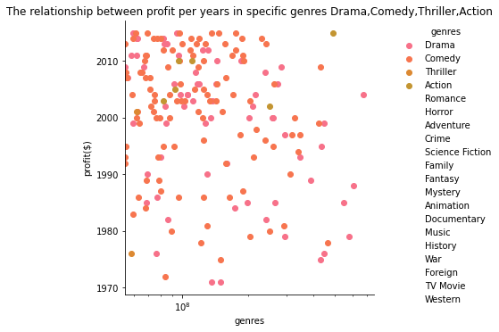

```python
genres_sub = df_clean_movies.loc[df_clean_movies['genres'].isin(['Drama','Comedy','Thriller','Action'])]
plt.figure(figsize = (17,10))
# plotting
g = sb.FacetGrid(data = genres_sub, hue = 'genres', size = 5)
g.map(plt.scatter, 'profit','release_year')
g.set(xscale = 'log') # need to set scaling before customizing ticks
plt.title('The relationship between profit per years in specific genres Drama,Comedy,Thriller,Action');
plt.ylabel('profit($)');
plt.xlabel('genres')
g.add_legend()
```

i listed only ('Drama','Comedy','Thriller','Action')in this graph to see the relationships between this genras with profit and release_year.. the most of movies lies in the recent 10 years

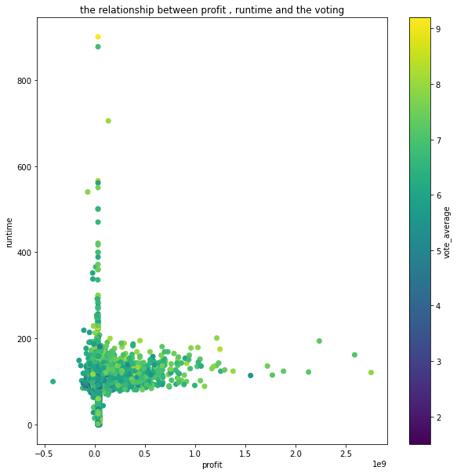

```python
plt.figure(figsize = [10,10])
plt.scatter(data = df_clean_movies, x = 'profit', y = 'runtime',
                c = 'vote_average')
plt.colorbar(label = 'vote_average')
plt.xlabel('profit')
plt.ylabel('runtime')
plt.title('the relationship between profit , runtime and the voting')
```

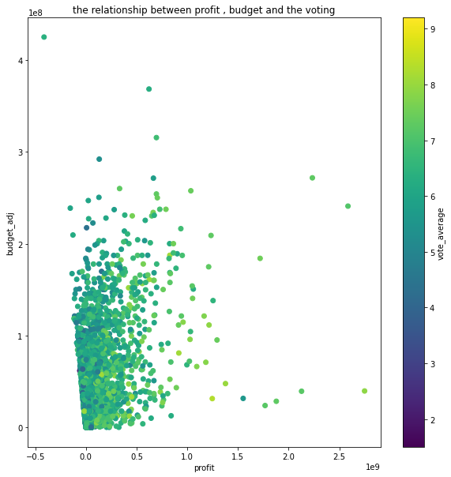

```python
plt.figure(figsize = [10,10])
plt.scatter(data = df_clean_movies, x = 'profit', y = 'budget_adj',
                c = 'vote_average')
plt.colorbar(label = 'vote_average')
plt.xlabel('profit')
plt.ylabel('budget_adj')
plt.title('the relationship between profit , budget and the voting')
```